# A report for the Maryland Department of transportation

This document is a starter report that fits the branding of the [Maryland Department of Transportation](https://joanjz.github.io/)

Author: Joan Jimenez

Date: October 10, 2024

## Introduction

Quarto is probably my favorite tool in the R/Python universe. Transforming your code and thoughts into a stunning report in one click always blows my mind.

While the default Quarto appearance **looks great**, there are [a few tweaks](https://www.productive-r-workflow.com/quarto-tricks) I always apply to elevate the report even further. Rather than manually adding them each time, I bundled everything into a custom format called `lumo`.

Btw, you can learn how to master Quarto thanks to my online course: [Productive R Workflow](https://www.productive-r-workflow.com)

This document aims at showcasing how a quarto document made with the `lumo` format looks like.

## Load Packages

Make sure to load **all your packages** at the start of your document for clarity and consistency.

Notice that the code chunks are folded by default. You can adjust this behavior with the `code-fold` option in the document’s YAML header.

```r
library(tidyverse)
library(hrbrthemes)
library(viridis)
library(ggiraph)
library(patchwork)
library(sf)
```

**1**

this package provides my favorite `ggplot2` theme: `theme_ipsum()`

**2**

because I was too lazy to find something better in the [R Color Finder](https://r-graph-gallery.com/color-palette-finder)!

By the way, you should open the code chunk that is folded above. ⬆️ There is a little stunning surprise on its right hand side.

## Main Features

### Typography

You may have noticed the typography differs from the default Quarto style. I’ve also added **extra spacing** above each title for better readability, and underlined them to make the headings stand out more.

### Header & Footer

The header is fully customized, complete with a fun GitHub corner linking to the original code. Plus, there are animated particles for a touch of whimsy. Scroll down, and you’ll find a custom footer as well.

For a complete list of features, [visit the documentation](https://www.productive-r-workflow.com/r/bonus/lumo-quarto-template)!

## How It Works

`Lumo` is a Quarto **custom format**. With a single command, you can add an `_extension` folder to your working directory, containing all the styles and content needed to create a report like this.

It takes less than 28 seconds, and you can find all the details [here](https://www.productive-r-workflow.com/r/bonus/lumo-quarto-template).

By the way, did you know you can link graphs together using [ggiraph](https://r-graph-gallery.com/package/ggiraph.html)? Its syntax is quite similar to `ggplot2` and it produces stunning, interactive outputs. Try hovering over one of the charts below!

Pretty close to magic, isn’t it?

```r
# Read the full world map
world_sf <- read_sf("https://raw.githubusercontent.com/holtzy/R-graph-gallery/master/DATA/world.geojson")
world_sf <- world_sf %>%
  filter(!name %in% c("Antarctica", "Greenland"))

# Create a sample dataset
happiness_data <- data.frame(
  Country = c(
    "France", "Germany", "United Kingdom",
    "Japan", "China", "Vietnam",
    "United States of America", "Canada", "Mexico"
  ),
  Continent = c(
    "Europe", "Europe", "Europe",
    "Asia", "Asia", "Asia",
    "North America", "North America", "North America"
  ),
  Happiness_Score = rnorm(mean = 30, sd = 20, n = 9),
  GDP_per_capita = rnorm(mean = 30, sd = 20, n = 9),
  Social_support = rnorm(mean = 30, sd = 20, n = 9),
  Healthy_life_expectancy = rnorm(mean = 30, sd = 20, n = 9)
)

# Join the happiness data with the full world map
world_sf <- world_sf %>%
  left_join(happiness_data, by = c("name" = "Country"))


# Create the first chart (Scatter plot)
p1 <- ggplot(world_sf, aes(
  GDP_per_capita,
  Happiness_Score,
  tooltip = name,
  data_id = Continent,
  color = Continent
)) +
  geom_point_interactive(data = filter(world_sf, !is.na(Happiness_Score)), size = 4) +
  theme_minimal() +
  theme(
    axis.title.x = element_blank(),
    axis.title.y = element_blank(),
    legend.position = "none"
  )

# Create the second chart (Bar plot)
p2 <- ggplot(world_sf, aes(
  x = reorder(name, Happiness_Score),
  y = Happiness_Score,
  tooltip = name,
  data_id = Continent,
  fill = Continent
)) +
  geom_col_interactive(data = filter(world_sf, !is.na(Happiness_Score))) +
  coord_flip() +
  theme_minimal() +
  theme(
    axis.title.x = element_blank(),
    axis.title.y = element_blank(),
    legend.position = "none"
  )

# Create the third chart (choropleth)
p3 <- ggplot() +
  geom_sf(data = world_sf, fill = "lightgrey", color = "lightgrey") +
  geom_sf_interactive(
    data = filter(world_sf, !is.na(Happiness_Score)),
    aes(fill = Continent, tooltip = name, data_id = Continent)
  ) +
  coord_sf(crs = st_crs(3857)) +
  theme_void() +
  theme(
    axis.title.x = element_blank(),
    axis.title.y = element_blank(),
    legend.position = "none"
  )

# Combine the plots
combined_plot <- (p1 + p2) / p3 + plot_layout(heights = c(1, 2))

# Create the interactive plot
interactive_plot <- girafe(ggobj = combined_plot)
interactive_plot <- girafe_options(
  interactive_plot,
  opts_hover(css = "fill:red;stroke:black;")
)

interactive_plot
```

[interactive chart not shown]

Figure: three graphs connected thanks to `ggiraph`

## Interactive table

It is very easy to insert an interactive table in your document thanks to the `DT` package. The output allows to filter rows, search for something and sort using a specific columns!

Install the library with `install.packages("DT")`. Then, just pass a dataframe to the `datatable()` function to get a stunning interactive output!

```r
library(DT)
data(iris)

# Make a table
datatable(iris, filter = "top")
```

|  | Sepal.Length | Sepal.Width | Petal.Length | Petal.Width | Species |
| --- | --- | --- | --- | --- | --- |
| 1 | 5.1 | 3.5 | 1.4 | 0.2 | setosa |
| 2 | 4.9 | 3 | 1.4 | 0.2 | setosa |
| 3 | 4.7 | 3.2 | 1.3 | 0.2 | setosa |
| 4 | 4.6 | 3.1 | 1.5 | 0.2 | setosa |
| 5 | 5 | 3.6 | 1.4 | 0.2 | setosa |
| 6 | 5.4 | 3.9 | 1.7 | 0.4 | setosa |
| 7 | 4.6 | 3.4 | 1.4 | 0.3 | setosa |
| 8 | 5 | 3.4 | 1.5 | 0.2 | setosa |
| 9 | 4.4 | 2.9 | 1.4 | 0.2 | setosa |
| 10 | 4.9 | 3.1 | 1.5 | 0.1 | setosa |

[output cut: 140 more lines]

I’ve added a bit of CSS to make the font smaller on DT tables by the way 🙂

## A grey section

It’s always good to have a grey section. Makes the document breath a bit. I’ve added a little utility class in `Lumo` to make sure you can make sections like this very easily. Check the [documentation](https://www.productive-r-workflow.com/r/bonus/lumo-quarto-template)!

Let’s use this space to render a little equation:

$$x = \frac{-b \pm \sqrt{b^2 - 4ac}}{2a}$$

## Quarto Tricks

`Lumo` is a great format, but to get the most out of it, you’ll need to master a few Quarto tricks!

The good news? I’ve compiled my 30+ favorite tips [in one place](https://www.productive-r-workflow.com/quarto-tricks). Just spend 30 minutes, and you’ll be up to speed with all of them!

For example, if you’re creating multiple plots, each highlighting different aspects of your dataset, consider using *pills* to organize them!

**Scatterplot**

This is a good old scatterplot of the iris dataset. If you want to learn more about how to make graphs in R, visit my [R graph gallery](https://www.r-graph-gallery.com)!

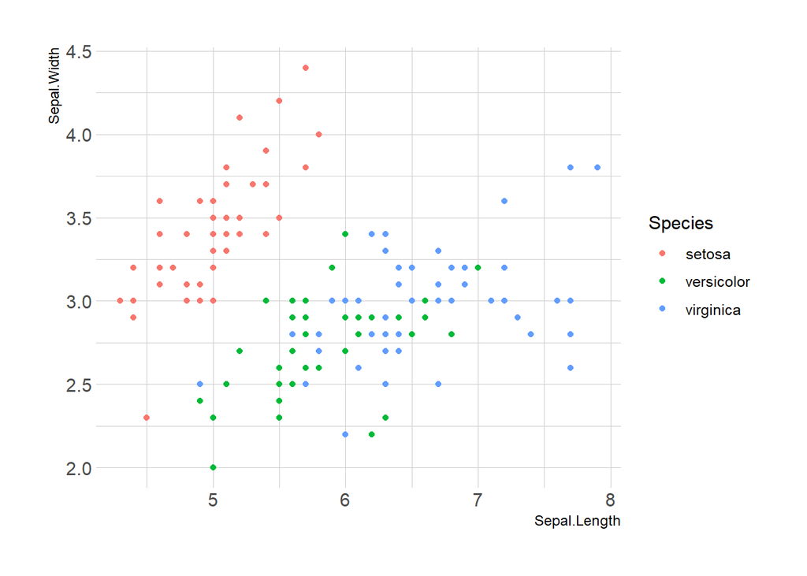

```r
ggplot(iris, aes(x=Sepal.Length, y=Sepal.Width, color=Species)) +
    geom_point() +
    theme_ipsum()
```

**Boxplot**

You can also make a [boxplot](https://r-graph-gallery.com/89-box-and-scatter-plot-with-ggplot2.html), but please do not hide the underlying distribution! This is widely explain in my data-to-viz.com project in case you’re not convinced 😋. Check the next tab to get convinced!

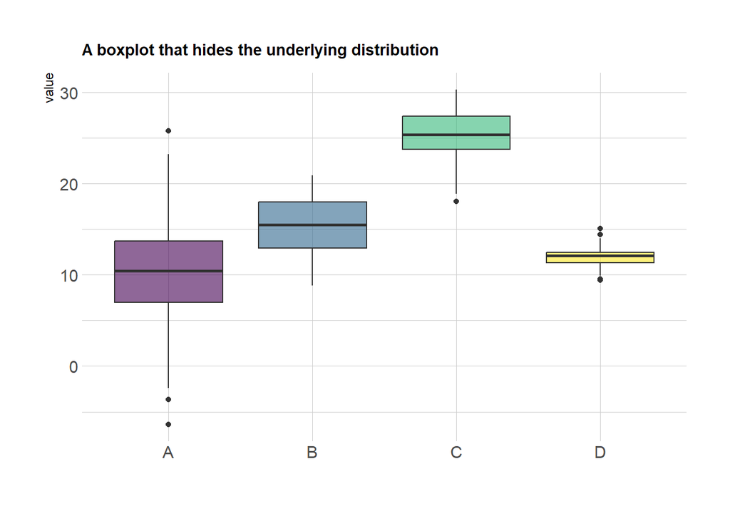

```r
# create a dataset
data <- data.frame(
  name=c( rep("A",500), rep("B",500), rep("B",500), rep("C",20), rep('D', 100)  ),
  value=c( rnorm(500, 10, 5), rnorm(500, 13, 1), rnorm(500, 18, 1), rnorm(20, 25, 4), rnorm(100, 12, 1) )
)

# Plot
data %>%
  ggplot( aes(x=name, y=value, fill=name)) +
    geom_boxplot() +
    scale_fill_viridis(discrete = TRUE, alpha=0.6) +
    theme_ipsum() +
    theme(
      legend.position="none",
      plot.title = element_text(size=11)
    ) +
    ggtitle("A boxplot that hides the underlying distribution") +
    xlab("")
```

**Jittering**

See what’s happening now that the individual data points are visible! Would be a shame to miss this.

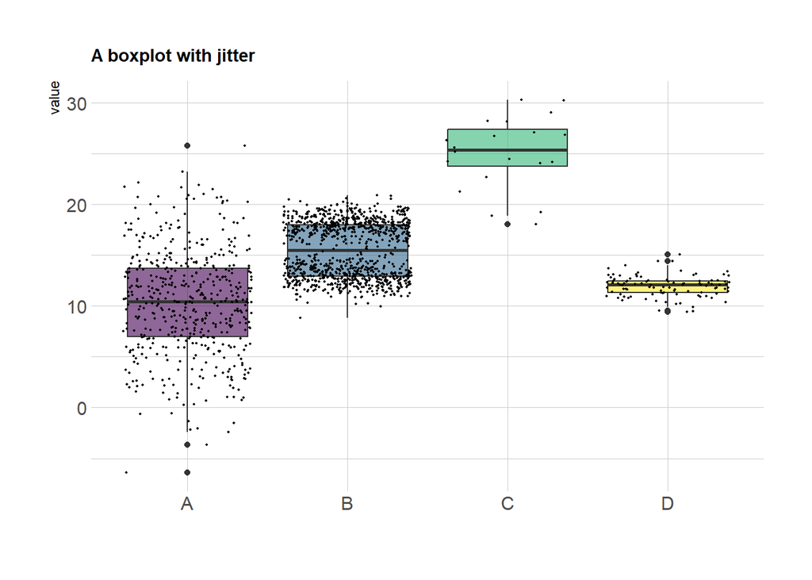

```r
data %>%
  ggplot( aes(x=name, y=value, fill=name)) +
    geom_boxplot() +
    scale_fill_viridis(discrete = TRUE, alpha=0.6) +
    geom_jitter(color="black", size=0.4, alpha=0.9) +
    theme_ipsum() +
    theme(
      legend.position="none",
      plot.title = element_text(size=11)
    ) +
    ggtitle("A boxplot with jitter") +
    xlab("")
```

## More Information

Learn how to use and how to customize `Lumo` [here](https://www.productive-r-workflow.com/r/bonus/lumo-quarto-template).

## Session Info

When creating a Quarto document, it’s a good practice to include details about your **working environment**.

This is easy to do—just call `sessionInfo()`, and it will print out all your R and package versions. This simple step greatly enhances **reproducibility**.

[session information not shown]

This document was made by the Maryland Department of Transportation, based on the [Lumo](https://www.productive-r-workflow.com/r/bonus/lumo-quarto-template) quarto template.